# CMSC/LING/STAT 208: ML - Homework 5

Jo Dang

### This homework assignment is intended as practice with feature engineering.

### **CAUTION**: The tasks in this assignment might take time to execute. Please be patient.

## Question 1

This problem concerns heart disease diagnosis based on certain characteristics of patients. You will work with the **HeartDisease.rds** dataset. Load the dataset into your R session using the following code.

```r
hd <- readRDS("HeartDisease.rds")
```

The dataset contains information on the following 14 variables.

- `age` - age in years
- `sex` - ‘male’ or ‘female’
- `cp` - chest pain type (1: typical angina; 2: atypical angina; 3: non-anginal pain; 4: asymptomatic)
- `trestbps` - resting blood pressure (in mm Hg on admission to the hospital)
- `chol` - serum cholesterol in mg/dl
- `fbs` - Is fasting blood sugar > 120 mg/dl? (‘TRUE’ or ‘FALSE’)
- `restecg` - resting electrocardiographic results (0, 1 or, 2)
- `thalach` - maximum heart rate achieved
- `exang` - exercise induced angina (‘yes’ or ‘no’)
- `oldpeak` - ST depression induced by exercise relative to rest
- `slope` - the slope of the peak exercise ST segment (1: upsloping; 2: flat; 3: downsloping)
- `ca` - number of major vessels (0-3) colored by fluoroscopy
- `thal` - one of ‘normal’, ‘fixed defect’, or ‘reversible defect’
- `target` - ‘Yes’ (presence of heart disease) or ‘No’ (absence of heart disease)

Consider `target` as the response variable and the rest of the variables as predictors.

The objective is to compare the performance (in terms of **Sensitivity**) of the following two models (both uses thresholds of 0.5):

- Logistic regression;
- $K$-NN classifier with optimal $K$ chosen by CV. Consider the grid of possible $K$ values given below.

**Perform the following tasks.**

- Investigate the data set and complete any necessary tasks.

```r
sum(is.na(hd)) #checking for NAs
```

```
## [1] 1313
```

```r
summary(hd)
```

```
##       age            sex                     cp         trestbps
##  Min.   :28.00   female:174   asymptomatic    :301   Min.   : 80.0
##  1st Qu.:45.00   male  :502   atypical angina :169   1st Qu.:120.0
##  Median :53.00                non-anginal pain:168   Median :130.0
##  Mean   :51.72                typical angina  : 38   Mean   :131.1
##  3rd Qu.:58.00                                       3rd Qu.:140.0
##  Max.   :76.00                                       Max.   :200.0
##                                                      NA's   :33
##       chol          fbs         restecg          thalach       exang
##  Min.   :  0.0   FALSE:539   Min.   :0.0000   Min.   : 69.0   no  :443
##  1st Qu.:195.0   TRUE : 83   1st Qu.:0.0000   1st Qu.:122.0   yes :200
##  Median :228.5   NA's : 54   Median :0.0000   Median :143.0   NA's: 33
##  Mean   :214.9               Mean   :0.5386   Mean   :141.8
##  3rd Qu.:269.0               3rd Qu.:1.0000   3rd Qu.:160.5
##  Max.   :603.0               Max.   :2.0000   Max.   :202.0
##  NA's   :26                  NA's   :2        NA's   :33
##     oldpeak                slope           ca                        thal
##  Min.   :-2.6000   downsloping: 29   Min.   :0.0000   fixed defect     : 24
##  1st Qu.: 0.0000   flat       :223   1st Qu.:0.0000   normal           :168
##  Median : 0.0000   upsloping  :164   Median :0.0000   reversible defect:101
##  Mean   : 0.6459   NA's       :260   Mean   :0.3991   NA's             :383
##  3rd Qu.: 1.2000                     3rd Qu.:1.0000
##  Max.   : 5.0000                     Max.   :3.0000
##  NA's   :36                          NA's   :453
##  target
##  No :411
##  Yes:265
##
##
##
##
##
```

```r
nearZeroVar(hd, saveMetrics = TRUE)
```

```
##          freqRatio percentUnique zeroVar   nzv
## age       1.482759      7.248521   FALSE FALSE
## sex       2.885057      0.295858   FALSE FALSE
## cp        1.781065      0.591716   FALSE FALSE
## trestbps  1.150538      8.136095   FALSE FALSE
## chol      9.111111     29.585799   FALSE FALSE
## fbs       6.493976      0.295858   FALSE FALSE
## restecg   3.448819      0.443787   FALSE FALSE
## thalach   1.275862     15.828402   FALSE FALSE
## exang     2.215000      0.295858   FALSE FALSE
## oldpeak   5.209677      6.360947   FALSE FALSE
## slope     1.359756      0.443787   FALSE FALSE
## ca        3.926829      0.591716   FALSE FALSE
## thal      1.663366      0.443787   FALSE FALSE
## target    1.550943      0.295858   FALSE FALSE
```

```r
#changing levels

hd$cp <- factor(hd$cp, levels = c("atypical angina", "typical angina", "non-anginal pain", "asymptomatic"))

hd$thal <- factor(hd$thal, levels = c("fixed defect", "reversible defect", "normal","NA's"))
```

- Split the data into training and test sets (consider a 70-30 split).

```r
# write your R code here
set.seed(2085)

index <- createDataPartition(y = hd$target, p = 0.7, list = FALSE)   # consider 70-30 split

hd_train <- hd[index,]   # training data

hd_test <- hd[-index,]   # test data
```

- Perform required data preprocessing and create the blueprint. If using `step_dummy()`, set `one_hot = FALSE`. Prepare the blueprint on the training data. Obtain the modified training and test datasets.

```r
# write your R code here
set.seed(2085)

hd_recipe <- recipe(formula = target ~ ., data = hd_train)   # sets up the type and role of variables

hd_recipe$var_info
```

```
## # A tibble: 14 × 4
##    variable type      role      source
##    <chr>    <list>    <chr>     <chr>
##  1 age      <chr [2]> predictor original
##  2 sex      <chr [3]> predictor original
##  3 cp       <chr [3]> predictor original
##  4 trestbps <chr [2]> predictor original
##  5 chol     <chr [2]> predictor original
##  6 fbs      <chr [3]> predictor original
##  7 restecg  <chr [2]> predictor original
##  8 thalach  <chr [2]> predictor original
##  9 exang    <chr [3]> predictor original
## 10 oldpeak  <chr [2]> predictor original
## 11 slope    <chr [3]> predictor original
## 12 ca       <chr [2]> predictor original
## 13 thal     <chr [3]> predictor original
## 14 target   <chr [3]> outcome   original
```

```r
blueprint <- hd_recipe %>%
  step_impute_mean(trestbps, chol, restecg, thalach, oldpeak, ca) %>%
  step_impute_knn(fbs, exang, slope, thal) %>%
  step_integer(cp,thal) %>%                                       # numeric conversion of levels of the predictors
  step_center(all_numeric(), -all_outcomes()) %>%                      # center (subtract mean) all numeric predictors
  step_scale(all_numeric(), -all_outcomes()) %>%                       # scale (divide by standard deviation) all numeric predictors
  step_dummy(all_nominal(), -all_outcomes(), one_hot = FALSE)                            # one-hot/dummy encode nominal categorical predictors

prepare <- prep(blueprint, data = hd_train)    # estimate feature engineering parameters based on training data

baked_train <- bake(prepare, new_data = hd_train)   # apply the blueprint to training data for building final/optimal model

baked_test <- bake(prepare, new_data = hd_test)    # apply the blueprint to test data for future use
```

- Implement 5-fold CV (no repeats) for each of the models above.

```r
# write your R code here
set.seed(2085)

cv_specs <- trainControl(method = "cv", number = 5, classProbs = TRUE, summaryFunction = twoClassSummary)   # 5-fold CV (no repeats)

# CV with logistic regression

logistic_fit <- train(blueprint,
                  data = hd_train,
                  method = "glm",
                  family = "binomial",
                  trControl = cv_specs,
                  metric = "Sens")
```

```r
k_grid <- expand.grid(k = seq(1, 25, by = 3))

knn_fit <- train(blueprint,
                  data = hd_train,
                  method = "knn",
                  trControl = cv_specs,
                  tuneGrid = k_grid,
                  metric = "Sens")
```

- Report the CV Sensitivity of each model. Report the optimal value of $K$ for the $K$-NN classifier. Which model performs better in this situation?

```r
logistic_fit
```

```
## Generalized Linear Model
##
## 474 samples
##  13 predictor
##   2 classes: 'No', 'Yes'
##
## Recipe steps: impute_mean, impute_knn, integer, center, scale, dummy
## Resampling: Cross-Validated (5 fold)
## Summary of sample sizes: 379, 379, 379, 379, 380
## Resampling results:
##
##   ROC        Sens       Spec
##   0.8506481  0.8194192  0.7103841
```

```r
knn_fit
```

```
## k-Nearest Neighbors
##
## 474 samples
##  13 predictor
##   2 classes: 'No', 'Yes'
##
## Recipe steps: impute_mean, impute_knn, integer, center, scale, dummy
## Resampling: Cross-Validated (5 fold)
## Summary of sample sizes: 379, 379, 380, 380, 378
## Resampling results across tuning parameters:
##
##   k   ROC        Sens       Spec
##    1  0.7222830  0.8156080  0.6182077
##    4  0.8309854  0.8017544  0.6823613
##    7  0.8440980  0.8262553  0.7200569
##   10  0.8636819  0.8471264  0.7041252
##   13  0.8693645  0.8435572  0.7150782
##   16  0.8592265  0.8576528  0.7149360
##   19  0.8610009  0.8367816  0.7256046
##   22  0.8667595  0.8090139  0.7149360
##   25  0.8651592  0.8298246  0.6987198
##
## Sens was used to select the optimal model using the largest value.
## The final value used for the model was k = 16.
```

[output not shown]

- Finally, with the optimal model, obtain probability and class label predictions on the test set (use threshold of 0.5). Create the corresponding confusion matrix and the ROC curve. Report the AUC.

```r
# predict probabilities

knnfit_prob_preds <- predict(object = knn_fit, newdata = hd_test, type = "prob")   # obtain predictions as probabilities

# predict class labels

threshold <- 0.5   # set threshold

knnfit_class_preds <- factor(ifelse(knnfit_prob_preds[,1] > threshold, "Yes", "No"))   # obtain predictions as class labels

# create confusion matrix

confusionMatrix(data = relevel(knnfit_class_preds, ref = "Yes"),
                reference = relevel(hd_test$target, ref = "Yes"))
```

```
## Confusion Matrix and Statistics
##
##           Reference
## Prediction Yes  No
##        Yes  22 100
##        No   57  23
##
##                Accuracy : 0.2228
##                  95% CI : (0.1674, 0.2865)
##     No Information Rate : 0.6089
##     P-Value [Acc > NIR] : 1.0000000
##
##                   Kappa : -0.4871
##
##  Mcnemar's Test P-Value : 0.0008024
##
##             Sensitivity : 0.2785
##             Specificity : 0.1870
##          Pos Pred Value : 0.1803
##          Neg Pred Value : 0.2875
##              Prevalence : 0.3911
##          Detection Rate : 0.1089
##    Detection Prevalence : 0.6040
##       Balanced Accuracy : 0.2327
##
##        'Positive' Class : Yes
##
```

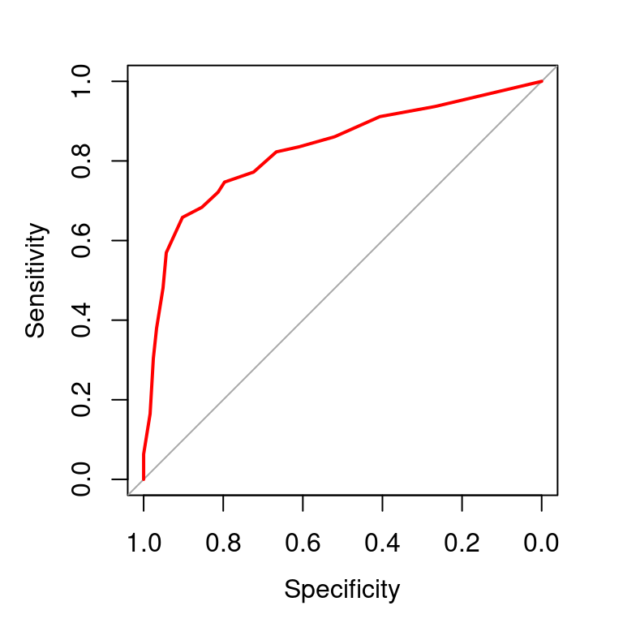

```r
library(pROC)   # load library

# create object for ROC curve for KNN fit

roc_object_knn <- roc(response = baked_test$target, predictor = knnfit_prob_preds[,1])

# plot ROC curve

plot(roc_object_knn, col = "red")
```

```r
# obtain AUC's

auc(roc_object_knn)
```

```
## Area under the curve: 0.8283
```

## Question 2

For this question, you will work with the **Credit** dataset which contains demographic and credit card information on 400 customers. Load the dataset using the following code.

```r
Credit <- readRDS("Credit.rds")
```

The dataset contains information on the following 11 variables.

- `Income` - Income in $1,000’s
- `Limit` - Credit limit
- `Rating` - Credit rating
- `Cards` - Number of credit cards
- `Age` - Age in years
- `Education` - Education in years
- `Own` - Does the individual own a home? (‘Yes’ or ‘No’)
- `Student` - Is the individual a student? (‘Yes’ or ‘No’)
- `Married` - Is the individual married? (‘Yes’ or ‘No’)
- `Region` - Geographical location (‘East’, ‘South’, ‘West’)
- `Balance` - Average credit card balance in $.

Consider `Balance` as the response variable and the rest of the variables as predictors.

The objective is to compare the performance (in terms of **RMSE**) of the following two models:

- A linear regression model;
- A $K$-NN regression model with optimal $K$ chosen by CV. Consider the grid of possible $K$ values given below.

**Perform the following tasks.**

- Investigate the dataset and complete any necessary tasks.

```r
sum(is.na(Credit)) #checking for NAs
```

```
## [1] 0
```

```r
nearZeroVar(hd, saveMetrics = TRUE)
```

```
##          freqRatio percentUnique zeroVar   nzv
## age       1.482759      7.248521   FALSE FALSE
## sex       2.885057      0.295858   FALSE FALSE
## cp        1.781065      0.591716   FALSE FALSE
## trestbps  1.150538      8.136095   FALSE FALSE
## chol      9.111111     29.585799   FALSE FALSE
## fbs       6.493976      0.295858   FALSE FALSE
## restecg   3.448819      0.443787   FALSE FALSE
## thalach   1.275862     15.828402   FALSE FALSE
## exang     2.215000      0.295858   FALSE FALSE
## oldpeak   5.209677      6.360947   FALSE FALSE
## slope     1.359756      0.443787   FALSE FALSE
## ca        3.926829      0.591716   FALSE FALSE
## thal      1.663366      0.443787   FALSE FALSE
## target    1.550943      0.295858   FALSE FALSE
```

- Split the data into training and test sets (consider a 80-20 split).

```r
# write your R code here
set.seed(2085)

index <- createDataPartition(y = Credit$Balance, p = 0.8, list = FALSE)   # consider 70-30 split

cr_train <- Credit[index,]   # training data

cr_test <- Credit[-index,]   # test data
```

- Perform required data preprocessing and create the blueprint. If using `step_dummy()`, set `one_hot = FALSE`. Prepare the blueprint on the training data. Obtain the modified training and test datasets.

```r
cr_recipe <- recipe(formula = Balance ~ ., data = cr_train)   # sets up the type and role of variables

cr_recipe$var_info
```

```
## # A tibble: 11 × 4
##    variable  type      role      source
##    <chr>     <list>    <chr>     <chr>
##  1 Income    <chr [2]> predictor original
##  2 Limit     <chr [2]> predictor original
##  3 Rating    <chr [2]> predictor original
##  4 Cards     <chr [2]> predictor original
##  5 Age       <chr [2]> predictor original
##  6 Education <chr [2]> predictor original
##  7 Own       <chr [3]> predictor original
##  8 Student   <chr [3]> predictor original
##  9 Married   <chr [3]> predictor original
## 10 Region    <chr [3]> predictor original
## 11 Balance   <chr [2]> outcome   original
```

```r
# write your R code here
set.seed(2085)

blueprint <- cr_recipe %>%
  step_center(all_numeric(), -all_outcomes()) %>%                      # center (subtract mean) all numeric predictors
  step_scale(all_numeric(), -all_outcomes()) %>%                       # scale (divide by standard deviation) all numeric predictors
  step_dummy(all_nominal(), one_hot = FALSE)                            # one-hot/dummy encode nominal categorical predictors

prepare <- prep(blueprint, data = cr_train)    # estimate feature engineering parameters based on training data

baked_train <- bake(prepare, new_data = cr_train)   # apply the blueprint to training data for building final/optimal model

baked_test <- bake(prepare, new_data = cr_test)    # apply the blueprint to test data for future use
```

```r
# write your R code here
set.seed(2085)

cv_specs <- trainControl(method = "cv", number = 5)   # 5-fold CV (no repeats)

# CV with logistic regression

lm_fit <- train(blueprint,
                  data = cr_train,
                  method = "lm",
                  trControl = cv_specs,
                  metric = "RMSE")
```

```r
k_grid <- expand.grid(k = seq(1, 25, by = 3))

knn_fit <- train(blueprint,
                  data = cr_train,
                  method = "knn",
                  trControl = cv_specs,
                  tuneGrid = k_grid,
                  metric = "RMSE")
```

- Report the CV RMSE each model. Report the the optimal value of $K$ for the $K$-NN model. Which model performs better in this situation?

```r
lm_fit
```

```
## Linear Regression
##
## 321 samples
##  10 predictor
##
## Recipe steps: center, scale, dummy
## Resampling: Cross-Validated (5 fold)
## Summary of sample sizes: 257, 257, 256, 257, 257
## Resampling results:
##
##   RMSE      Rsquared   MAE
##   98.41789  0.9568017  78.45459
##
## Tuning parameter 'intercept' was held constant at a value of TRUE
```

```r
knn_fit
```

```
## k-Nearest Neighbors
##
## 321 samples
##  10 predictor
##
## Recipe steps: center, scale, dummy
## Resampling: Cross-Validated (5 fold)
## Summary of sample sizes: 256, 257, 257, 257, 257
## Resampling results across tuning parameters:
##
##   k   RMSE      Rsquared   MAE
##    1  268.3253  0.6667605  187.0625
##    4  222.4195  0.7751809  160.7733
##    7  215.7938  0.8007702  160.4920
##   10  219.1908  0.8017954  166.3458
##   13  221.6918  0.7998403  166.9311
##   16  223.0783  0.8076712  170.7310
##   19  227.7558  0.8080827  174.1269
##   22  233.6808  0.8000250  178.8874
##   25  238.3330  0.7944841  182.7327
##
## RMSE was used to select the optimal model using the smallest value.
## The final value used for the model was k = 7.
```

```
The CV RMSE of the linear regression model is 98.41789.
The lowest CV RMSE of the knn classifier is 215.7938 at k = 7.
In this case, the linear regression model performs better.
```

- Finally, with the optimal model, obtain predictions on the test set. Calculate and report the test set RMSE.

```r
final_model <- lm(Balance ~ ., data = baked_train)    # build final model

final_preds <- predict(object = final_model, newdata = baked_test)   # obtain predictions on test data

sqrt(mean((baked_test$Balance - final_preds)^2))    # calculate test set RMSE
```

```
## [1] 110.7068
```